# 植生調査資料の解析

松村 俊和

### 甲南女子大学 2025-11-21

# 解説の内容

- 基礎的・一般的な手法を紹介
  - 他にも色々とある
  - 書籍や論文で学ぶ
- 生成AIに質問すれば教えてくれる
  - 基本的な考え方の理解が重要
  - ブラックボックスではダメ
- 間違いがあればご指摘ください

## 全体像

- 調査資料の取り扱い
- 解析手法の種類
  - 多様性指数
  - クラスター分析
  - 序列化
  - 指標種分析
- 演習編
  - 準備
  - 前処理
  - 解析・図化

# 調査資料の取り扱い

- Tidyな形式で保存
- パソコンへの入力方法
- データの種類と変換

## Tidyとは

- Hadley (2014)
- 整然とした状態：データ解析では必須
  - 1つの変数が1つの列
  - 1つの観測が1つの行
  - 1つのタイプの観測群が1つの表
  - 1つの値が1つのセル

## Tidy vs Messy

“Happy families are all alike;  
every unhappy family is unhappy in its own way.”  
— Leo Tolstoy

“Tidy datasets are all alike,  
but every messy dataset is messy in its own way.”  
— Hadley Wickham

## Messy data

```r
tidyr::table2
```

```
## # A tibble: 12 × 4
##    country      year type            count
##    <chr>       <dbl> <chr>           <dbl>
##  1 Afghanistan  1999 cases             745
##  2 Afghanistan  1999 population   19987071
##  3 Afghanistan  2000 cases            2666
##  4 Afghanistan  2000 population   20595360
##  5 Brazil       1999 cases           37737
##  6 Brazil       1999 population  172006362
##  7 Brazil       2000 cases           80488
##  8 Brazil       2000 population  174504898
##  9 China        1999 cases          212258
## 10 China        1999 population 1272915272
## 11 China        2000 cases          213766
## 12 China        2000 population 1280428583
```

## Tidy data

```r
tidyr::table2 |>
  tidyr::pivot_wider(
    id_cols = c(country, year),
    names_from = type,
    values_from = count)
```

```
## # A tibble: 6 × 4
##   country      year  cases population
##   <chr>       <dbl>  <dbl>      <dbl>
## 1 Afghanistan  1999    745   19987071
## 2 Afghanistan  2000   2666   20595360
## 3 Brazil       1999  37737  172006362
## 4 Brazil       2000  80488  174504898
## 5 China        1999 212258 1272915272
## 6 China        2000 213766 1280428583
```

## 植生データの種類

- 地点：地点, 緯度, 経度, 標高, 日時, …
- 組成：地点, 階層, 種名, 被度, …
- 種：種名, 科, 生活型, 機能型, …

## パソコンへの入力・保存

- 1行目は項目名
- 空の行，空の列，空のセルはつくらない
- テキストファイル(CSV or TSV)で保存(推奨)
  - 誤変換を防ぐ
  - 再利用が容易
  - `openxlsx::read.xlsx()`，`readr::write_csv()`
- スプレッドシートでの保存
  - 組成, 地点, 種を別シートに入力
  - 文字列として保存(誤変換対策)
  - `openxlsx::write.xlsx()`

## データの種類と変換

- 百分率
- Braun-Blanquetの階級値
- 在・不在
- 平方根変換
- 対数変換
- 相対優占度
- Hellinger変換

## データの種類と変換

```r
bb_scale <- c("5", "4", "3", "2", "1", "+", "r", "0")
percentage <- c(75, 50, 25, 10, 1, 0.1, 0.01, 0)
percen_med <- (percentage + lag(percentage, default = 100)) / 2
percen_med[length(percen_med)] <- 0
pa <- purrr::map_dbl(percentage > 0, sum)
squared <- percentage^0.5
logged <- log10(percentage + 1) # +1: 1未満を正
tibble::tibble(bb_scale, percentage, percen_med, pa, squared, logged)
```

```
## # A tibble: 8 × 6
##   bb_scale percentage percen_med    pa squared  logged
##   <chr>         <dbl>      <dbl> <dbl>   <dbl>   <dbl>
## 1 5             75         75        1   8.66  1.88
## 2 4             50         50        1   7.07  1.71
## 3 3             25         25        1   5     1.41
## 4 2             10         10        1   3.16  1.04
## 5 1              1          1        1   1     0.301
## 6 +              0.1        0.1      1   0.316 0.0414
## 7 r              0.01       0.01     1   0.1   0.00432
## 8 0              0          0        0   0     0
```

## 相対優占度

- nij：地点jでの種iの出現量(被度や個体数)
- Nj：地点jの全種の出現量の合計  
  Nj = Σnij
- Pij：地点jでの種iの相対優占度  
  Pij = nij / Nj

```r
val <- c(4, 3, 2, 1)
val / sum(val)
```

```
## [1] 0.4 0.3 0.2 0.1
```

## Hellinger変換

- 相対優占度の平方根

```r
val <- c(4, 3, 2, 1)
proportion <- val / sum(val)
proportion ^ 0.5
```

```
## [1] 0.6324555 0.5477226 0.4472136 0.3162278
```

# 解析の種類

- 多様性指数：α, β, γ
- 分類：クラスター分析  
  TwinSpan, 分類回帰樹木, …
- 序列化(Ordination)：PCA, PCoA, DCA, nMDS,  
  CCA, RDA, …
- 指標種分析(ISA：Indicator Species Analsis)
- その他
  - Rarefaction Curve
  - 時系列分析
  - 分布モデル

# 多様性指数

- α：地点内の多様性
  - 1地点あたりの種数
  - 均等度の考慮の有無
- β：地点間の多様性(類似度)
  - β = γ / α
  - β = γ - α
- γ：地域内の多様性
- 地点・地域の大きさは任意

## α多様性

- 主な指数
  - 種数：S
- Simpsonの均等度
  - d = Σ(Pij)^2
  - 1 - d：均等度のみ考慮
  - 1 / d：均等度と種数を考慮
- Shannonの情報量：H’
  - H’ = -Σ(Pij・ln(Pij))

## Simpsonの均等度指数

```r
val <- rep(20, 5)  # 5種とも全て20のとき
nj <- sum(val)     # 出現量の合計
pi <- val / nj     # 相対優占度
d <- sum(pi^2)
c(d, 1-d, 1/d)
```

```
## [1] 0.2 0.8 5.0
```

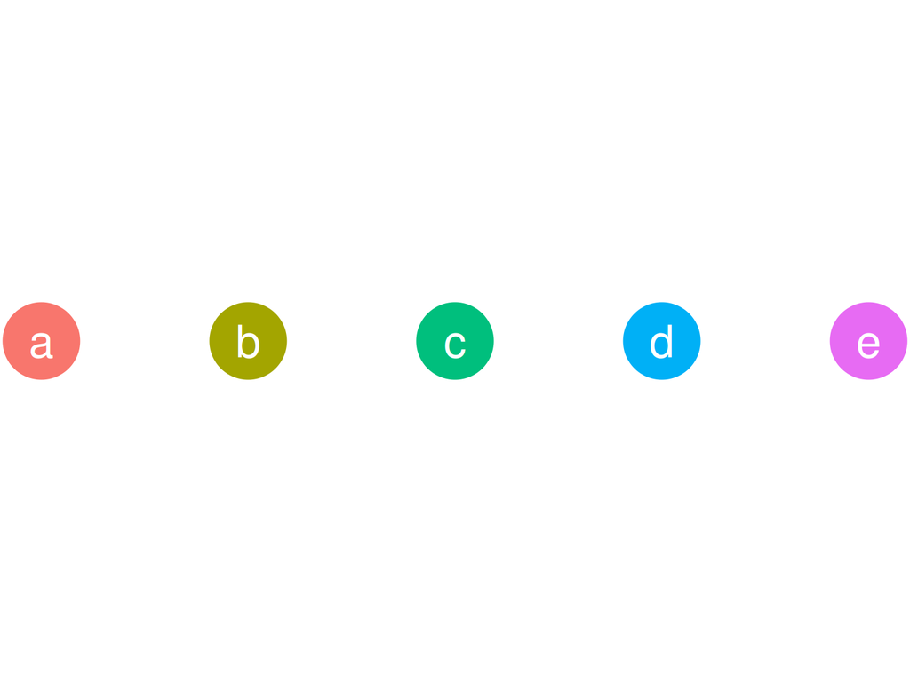

## Simpsonの均等度指数

```r
val <- c(10, 10, 60, 10, 10) # 1種が60,他が10
nj <- sum(val)     # 出現量の合計
pi <- val / nj     # 相対優占度
d <- sum(pi^2)
c(d, 1-d, 1/d)
```

```
## [1] 0.4 0.6 2.5
```

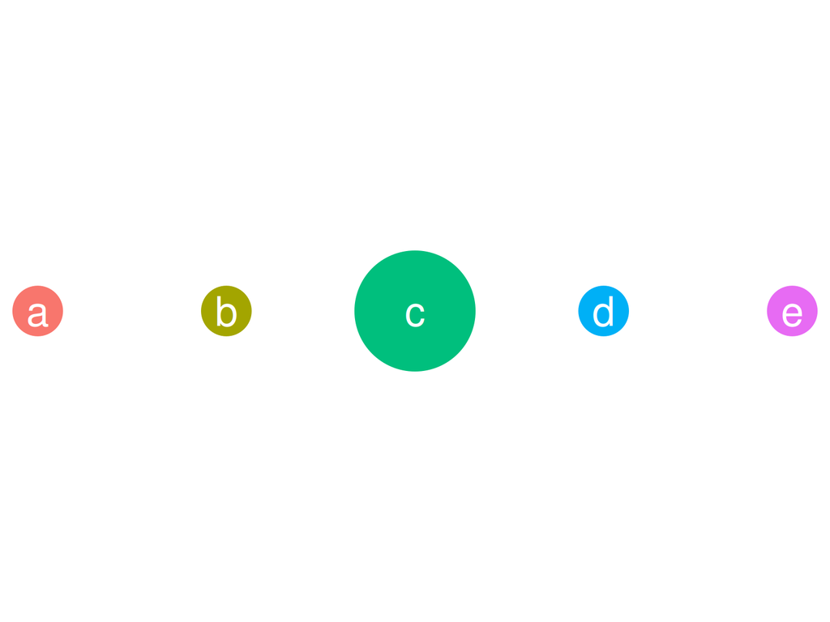

## α多様性のまとめ

- 基本情報としての種数
- 均等度と種数を考慮：1/dが理解しやすい
  - 最小値：1
  - 最大値：S(全種が均等)
- 均等度重視：1 - d

## β多様性・γ多様性

- β多様性は γ / α または γ - α
  - 一般的にはγ / α
  - 比較の際には定義の確認が必要
- γ多様性の算出方法はα多様性と同様

# クラスター分析

- 地点あるいは種を分類
- 地点の分類：種の出現の仕方(類似度)を算出
- 方法
  - 地点(種)間の類似度を計算
  - 「近いもの」を結合
- 類似度と結合方法によって結果が異なる
- グループ内での並び順は無意味

## クラスター分析の考え方：データ

```r
data(USArrests)
tibble::tibble(USArrests)
```

```
## # A tibble: 50 × 4
##    Murder Assault UrbanPop  Rape
##     <dbl>   <int>    <int> <dbl>
##  1   13.2     236       58  21.2
##  2   10       263       48  44.5
##  3    8.1     294       80  31
##  4    8.8     190       50  19.5
##  5    9       276       91  40.6
##  6    7.9     204       78  38.7
##  7    3.3     110       77  11.1
##  8    5.9     238       72  15.8
##  9   15.4     335       80  31.9
## 10   17.4     211       60  25.8
## # ℹ 40 more rows
```

## クラスター分析の考え方：類似度の計算

```r
USArrests |>
  head(7) |>
  stats::dist() |>
  round(2)
```

```
##             Alabama Alaska Arizona Arkansas California Colorado
## Alaska        37.18
## Arizona       63.01  46.59
## Arkansas      46.93  77.20  108.85
## California    55.52  45.10   23.19    97.58
## Colorado      41.93  66.48   90.35    36.73      73.20
## Connecticut  128.21 159.41  185.16    85.03     169.28    98.08
```

## クラスター分析の考え方：プロット

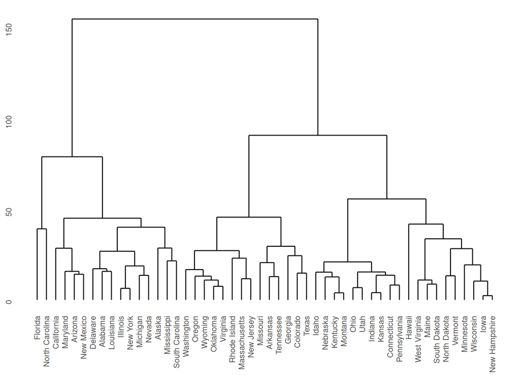

## 類似度

- メトリック
  - ユークリッド距離  
    ( (x1 - x2)^2 + (y1 - y2)^2 )^0.5
  - Hellinger距離  
    Hellinger変換してからユークリッド距離を計算
  - マンハッタン距離(碁盤の目の移動)  
    |x1-x2| + |y1-y2|
- 非メトリック
  - Bray-Curtis距離：マンハッタン距離を標準化  
    (|x1-x2| + |y1-y2|) / ((x1+x2) + (y1+y2))

## ユークリッド距離(実践)とマンハッタン距離(点線)

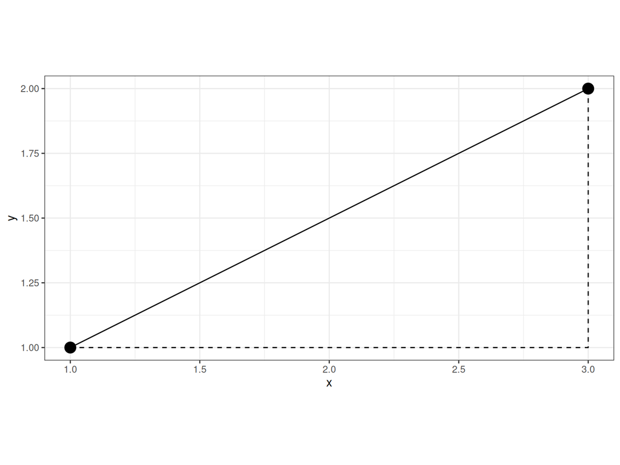

## 主な結合方法

- 最近隣法
  - 説明でよく使われる
  - 欠点：鎖状につながりやすい
- 非加重群平均法(UPGMA)
  - グループ結合後に距離を再計算
  - 非メトリックな距離も可能
- Ward法
  - クラスター内の分散を最小化
  - メトリックな距離のみ

## 結合方法の比較

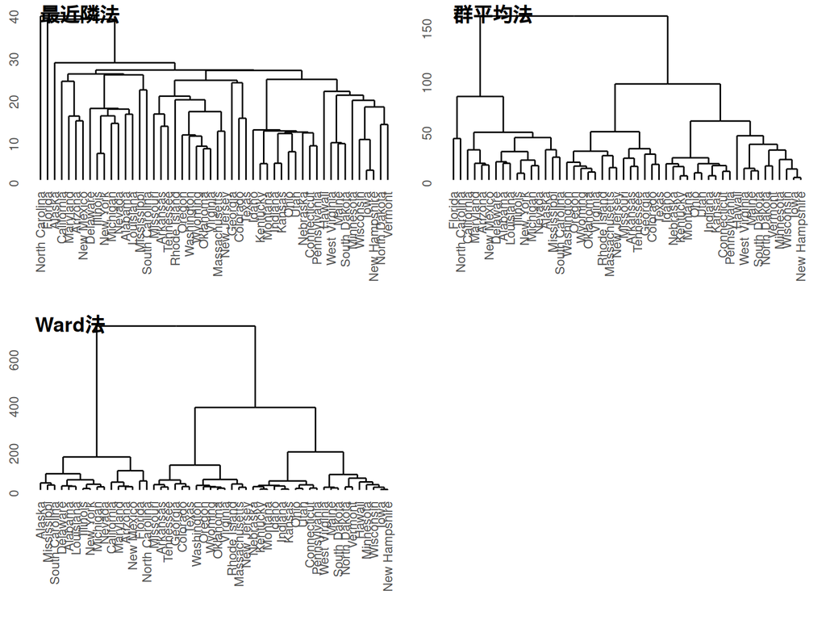

## クラスター分析のまとめ

- 地点や種を結合
- 1次元的
- 一般的な組み合わせ
  - Bray-Curtis距離 + 非荷重群平均法
  - Hellinger距離 + Ward法 (“ward.D2”)

# 序列化, Ordination

- 手法は多種多様
  - PCA：主成分分析
  - CA：対応分析
  - DCA：除歪対応分析
  - PCoA：主座標分析
  - nMDS：非計量多次元尺度法
  - CCA：正準相関分析  
    長い環境傾度との対応
  - RDA：冗長性分析  
    短い環境傾度との対応
- 類似度との組み合わせで結果が異なる

## PCA：主成分分析

- Principal Component Analysis
- 次元削減
  - 多変量から相関のない成分で説明
  - 一般的には第1軸と第2軸でほぼ説明
  - 入力はメトリックな距離のみ
- 馬蹄(アーチ)効果

## PCAの考え方

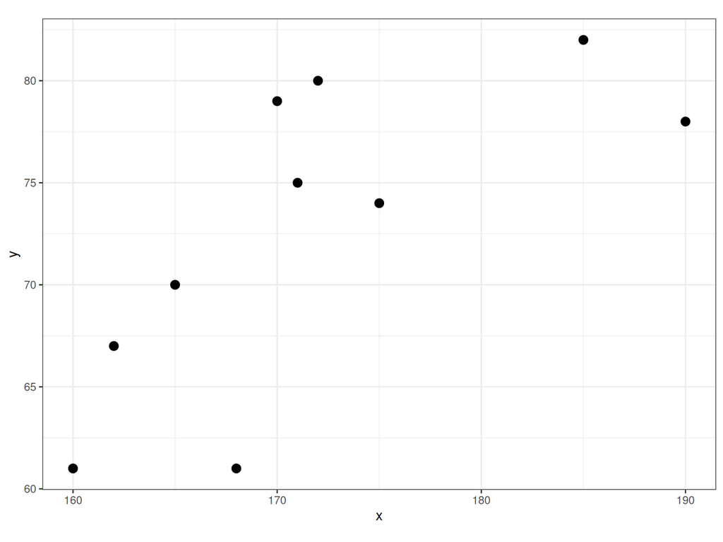

## PCAの考え方

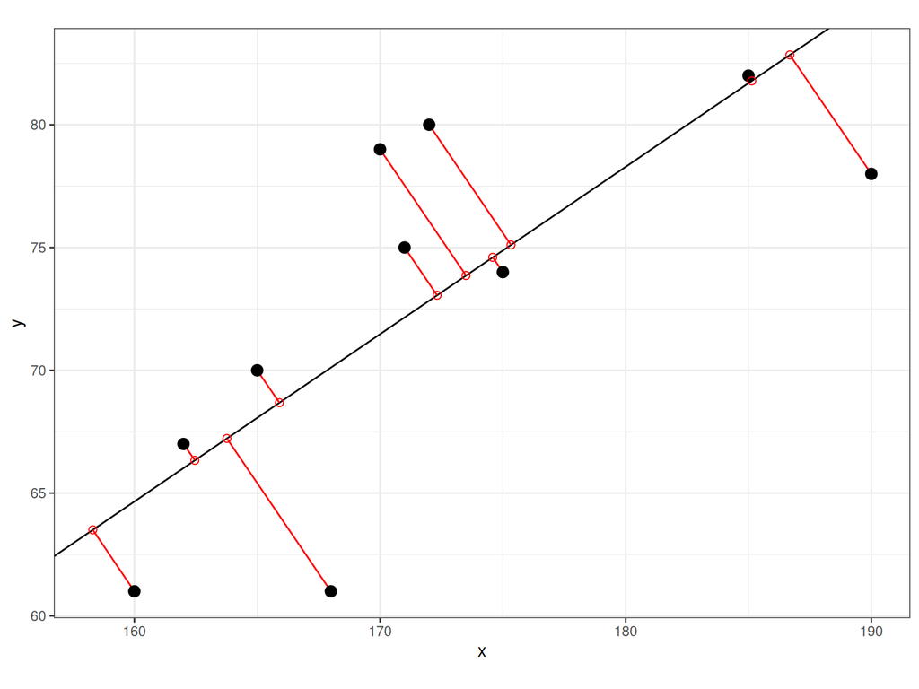

## PCAの考え方

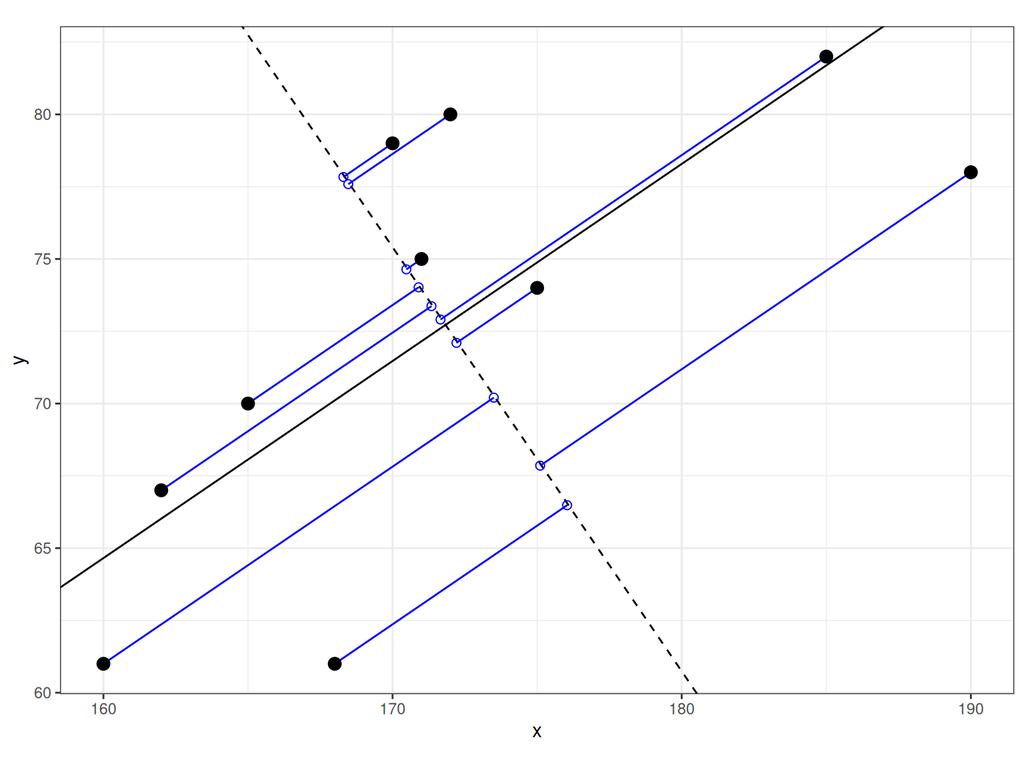

## 馬蹄(アーチ)効果

- 長い環境傾度
- アーチ状に配置
- 入れ替わりが一定のデータ
  - 類似度だけなら，直線上にならぶはず
  - 類似度が低いはずの地点が近くに配置される

## 馬蹄効果の例(データ)

```
##      st01 st02 st03 st04 st05 st06 st07 st08 st09 st10
## sp01    1    0    0    0    0    0    0    0    0    0
## sp02    2    1    0    0    0    0    0    0    0    0
## sp03    3    2    1    0    0    0    0    0    0    0
## sp04    2    3    2    1    0    0    0    0    0    0
## sp05    1    2    3    2    1    0    0    0    0    0
## sp06    0    1    2    3    2    1    0    0    0    0
## sp07    0    0    1    2    3    2    1    0    0    0
## sp08    0    0    0    1    2    3    2    1    0    0
## sp09    0    0    0    0    1    2    3    2    1    0
## sp10    0    0    0    0    0    1    2    3    2    1
## sp11    0    0    0    0    0    0    1    2    3    2
## sp12    0    0    0    0    0    0    0    1    2    3
## sp13    0    0    0    0    0    0    0    0    1    2
## sp14    0    0    0    0    0    0    0    0    0    1
```

## 馬蹄効果の例

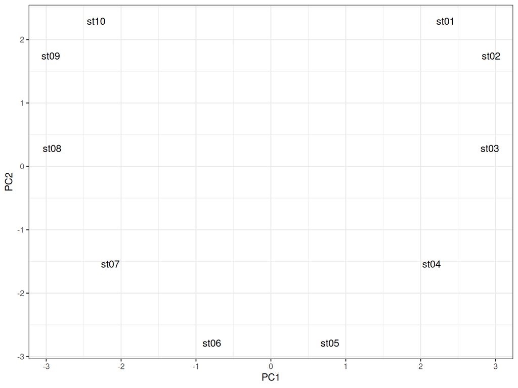

## DCA：除歪対応分析

- Detrended Component Analysis
- 植生以外ではあまり使われない

## PCoA：主座標分析

- Principal Coordinate Analysis
- 元の距離をできるだけ保持した低次元空間
- 任意の距離(Bray-Curtis距離など)が使用可能
- ユークリッド距離ではPCAと同じ結果
- 計算結果は一意に決定

## nMDS：非計量多次元尺度法

- non-metric Multidimensional Scaling
- 任意の距離(Bray-Curtis距離など)が使用可能
- 距離の大小関係(順序)を維持した低次元空間
- 非線形・複雑な構造のデータに適している
- 反復計算でStress valueを計算
  - 局所解に陥る可能性あり
  - 軸の向きに意味なし
  - < 0.2：許容範囲
  - < 0.1：良い
  - < 0.05：非常に良い

## CCA：正準相関分析とRDA：冗長性分析

- Canonical Correspondence Analysis
  - CAの環境要因対応版
  - 任意の距離
  - 環境変数の幅が長いとき
- Redundancy Analysis
  - PCAの環境変数対応版
  - メトリックな距離
  - 環境変数の幅が短いとき

## 序列化のまとめ

- 2次元座標への配置  
  本当は多次元だが, 実質的には2次元が多い
- Bray-Curtis距離 + PCoA or nMDS
- 環境要因対応版
  - 長い傾度：CCA
  - 短い傾度：RDA

# 指標種分析

- 特定のグループに特徴的に出現する種を抽出
- 在・不在，出現量のどちらでも可能
- Dufrene and Legendre (1997)
- 無作為化検定(Permutation test)が可能

## 指標値の計算

- IV = (Cij / Ci) * (Fij/ Fj) * 100
  - Cij：種iのグループjでの出現量
  - Ci：種iの全体での出現量
  - Fij：種iのグループjでの出現回数
  - Fj：種iの全体での出現回数

# データ分析の実演

- パッケージの準備
- veganパッケージのデータ
- 前処理：かなり重要
- α多様性
- クラスター分析
- 序列化
- 指標種分析

## 参考URL

- https://matutosi.github.io/ecan/ とほぼ同じ内容
- https://matutosi.shinyapps.io/ecanvis/ でも実行可能

# 準備：パッケージのインストール

```r
install.packages("tidyverse")  # コードを明快に
install.packages("vegan")      # 植生解析の定番
install.packages("ecan")       # 解析を簡単に
install.packages("dendextend") # 図示で使用
install.packages("ggdendro")   # 図示で使用
install.packages("ggrepel")    # 図示で使用
install.packages("ggsci")      # 図示で使用
install.packages("cowplot")    # 図示で使用
```

## 準備：パッケージの呼び出し

```r
library(vegan)
library(ecan)
library(tidyverse)
library(ggdendro)
library(ggrepel)
library("ggsci")
library("cowplot")
```

# 基本データの準備(演習)

- データの読み込み
- 前処理
- 結合

## データの読み込み(例)

```r
  # CSVのとき
path_stand <- "c:/hoge/huga/stand.csv"
df_st <- readr::read_csv(path_stand)
  # Excelのとき
path_data <- "c:/hoge/huga/data.xlsx"
df_st <- openxlsx::read.xlsx(path_data, sheet = 1)
```

## dune.envデータ(地点)

```r
data(dune.env, package = "vegan") # 地点
dune_env_df <-
  tibble::tibble(dune.env) |> # A1, Moistureなどの情報
  tibble::rownames_to_column("stand") |> # 地点名を列に変換
  print(n = 8)                           # 8行のみ
```

```
## # A tibble: 20 × 6
##   stand    A1 Moisture Management Use      Manure
##   <chr> <dbl> <ord>    <fct>      <ord>    <ord>
## 1 1       2.8 1        SF         Haypastu 4
## 2 2       3.5 1        BF         Haypastu 2
## 3 3       4.3 2        SF         Haypastu 4
## 4 4       4.2 2        SF         Haypastu 4
## 5 5       6.3 1        HF         Hayfield 2
## 6 6       4.3 1        HF         Haypastu 2
## 7 7       2.8 1        HF         Pasture  3
## 8 8       4.2 5        HF         Pasture  3
## # ℹ 12 more rows
```

## duneデータ(組成)

```r
data(dune, package = "vegan") # 組成
tibble(dune) |>         # 0-9の値
  dplyr::select(1:5) |> # 5列のみ表示
  print(n = 8)          # 8行のみ
```

```
## # A tibble: 20 × 5
##   Achimill Agrostol Airaprae Alopgeni Anthodor
##      <dbl>    <dbl>    <dbl>    <dbl>    <dbl>
## 1        1        0        0        0        0
## 2        3        0        0        2        0
## 3        0        4        0        7        0
## 4        0        8        0        2        0
## 5        2        0        0        0        4
## 6        2        0        0        0        3
## 7        2        0        0        0        2
## 8        0        4        0        5        0
## # ℹ 12 more rows
```

## duneデータの変換

```r
dune_df <-
  dune |>         # 組成表形式
  ecan::table2df( # df形式に変換
    st = "stand",
    sp = "species",
    ab = "cover")
dune_df
```

```
## # A tibble: 197 × 3
##    stand species  cover
##    <chr> <chr>    <dbl>
##  1 1     Achimill     1
##  2 1     Elymrepe     4
##  3 1     Lolipere     7
##  4 1     Poaprat      4
##  5 1     Poatriv      2
##  6 2     Achimill     3
##  7 2     Alopgeni     2
##  8 2     Bellpere     3
##  9 2     Bromhord     4
## 10 2     Elymrepe     4
## # ℹ 187 more rows
```

## 種データ(ダミー)

```r
sp_dummy <- tibble::tibble(
  "species" = colnames(dune),
  "dummy_1" = stringr::str_sub(colnames(dune), 1, 1), # 1文字目
  "dummy_6" = stringr::str_sub(colnames(dune), 6, 6)) # 6文字目
print(sp_dummy, n = 8)
```

```
## # A tibble: 30 × 3
##   species  dummy_1 dummy_6
##   <chr>    <chr>   <chr>
## 1 Achimill A       i
## 2 Agrostol A       t
## 3 Airaprae A       r
## 4 Alopgeni A       e
## 5 Anthodor A       d
## 6 Bellpere B       e
## 7 Bromhord B       o
## 8 Chenalbu C       l
## # ℹ 22 more rows
```

## 結合

```r
df <-
    dune_df |>                       # 組成
    dplyr::left_join(dune_env_df) |> # 地点
    dplyr::left_join(sp_dummy)       # 種
```

## 結合：基本データの完成!

```r
df |>
  dplyr::select(1:5, 9:10) |>
  print(n = 8)
```

```
## # A tibble: 197 × 7
##   stand species  cover    A1 Moisture dummy_1 dummy_6
##   <chr> <chr>    <dbl> <dbl> <ord>    <chr>   <chr>
## 1 1     Achimill     1   2.8 1        A       i
## 2 1     Elymrepe     4   2.8 1        E       e
## 3 1     Lolipere     7   2.8 1        L       e
## 4 1     Poaprat      4   2.8 1        P       a
## 5 1     Poatriv      2   2.8 1        P       i
## 6 2     Achimill     3   3.5 1        A       i
## 7 2     Alopgeni     2   3.5 1        A       e
## 8 2     Bellpere     3   3.5 1        B       e
## # ℹ 189 more rows
```

# α多様性(演習)

- s: 種数
- h: Shannon’s H’
- d: Simpson’s index (1 - D)
- i: Simpson’s inverse (1 / D)

## α多様性の計算

```r
div <-
  ecan::shdi(df,
             stand = "stand",
             species = "species",
             abundance = "cover")
print(div, n = 8)
```

```
## # A tibble: 20 × 5
##   stand     s     h     d     i
##   <chr> <int> <dbl> <dbl> <dbl>
## 1 1         5  1.44 0.735  3.77
## 2 10       12  2.40 0.903 10.3
## 3 11        9  2.11 0.867  7.53
## 4 12        9  2.11 0.869  7.61
## 5 13       10  2.10 0.852  6.76
## 6 14        7  1.86 0.833  6
## 7 15        8  1.98 0.851  6.70
## 8 16        8  1.96 0.843  6.37
## # ℹ 12 more rows
```

## α多様性(グループ別の平均値)

```r
dune_env_df <-
  dplyr::left_join(dune_env_df, div) # 地点を結合
dune_env_df |>
  dplyr::group_by(Management) |> # Managementでグループ化
  dplyr::summarise_if(is.numeric, mean) # 数値の列で平均
```

```
## # A tibble: 4 × 6
##   Management    A1     s     h     d     i
##   <fct>      <dbl> <dbl> <dbl> <dbl> <dbl>
## 1 BF          3.43 10.3   2.25 0.887  8.98
## 2 HF          4.26 12.6   2.46 0.908 10.9
## 3 NM          6.1   8     2.00 0.854  6.92
## 4 SF          4.8   9.17  2.04 0.846  7.14
```

## α多様性の図示(コード)

```r
diversity_gg <-
  dune_env_df |>
  ggplot2::ggplot(
    ggplot2::aes(x = Management, y = i)) + # 1 / d
  ggplot2::geom_boxplot(outlier.shape = NA) +
  ggplot2::geom_jitter(height = 0, width = 0.1) +
  ggplot2::theme_bw()
```

## α多様性の図示

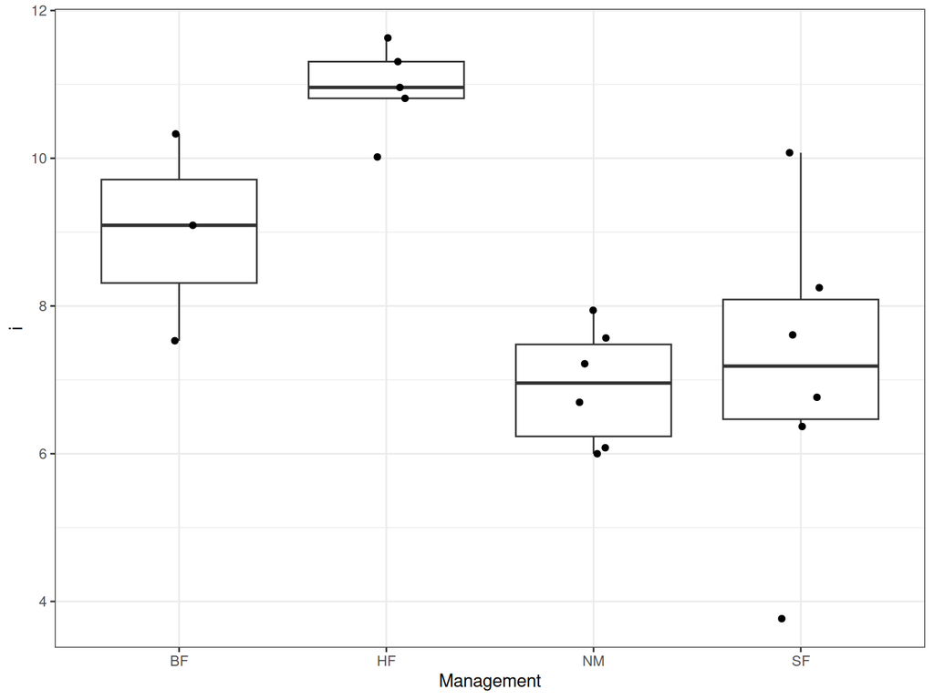

```r
diversity_gg
```

# クラスター分析(演習)

```r
cls <-
  df |>
  # 組成形式に
  ecan::df2table(st = "stand", sp = "species", ab = "cover") |>
  ecan::cluster(
    c_method = "average", # 非荷重群平均方
    d_method = "bray")    # Bray-Curtis距離
cls # 結果の表示(実施方法のみ)
```

```
##
## Call:
## stats::hclust(d = d, method = c_method)
##
## Cluster method   : average
## Distance         : bray
## Number of objects: 20
```

## クラスター分析の結果

```r
str(cls)
```

```
## List of 9
##  $ merge            : int [1:19, 1:2] -6 -5 -3 -2 -15 -8 -11 -16 -12 3 ...
##  $ height           : num [1:19] 0.227 0.263 0.271 0.294 0.296 ...
##  $ order            : int [1:20] 14 16 15 20 17 19 1 12 13 3 ...
##  $ labels           : chr [1:20] "1" "2" "3" "4" ...
##  $ method           : chr "average"
##  $ call             : language stats::hclust(d = d, method = c_method)
##  $ dist.method      : chr "bray"
##  $ clustering_method: chr "average"
##  $ distance_method  : chr "bray"
##  - attr(*, "class")= chr "hclust"
```

## クラスター分析結果の図示

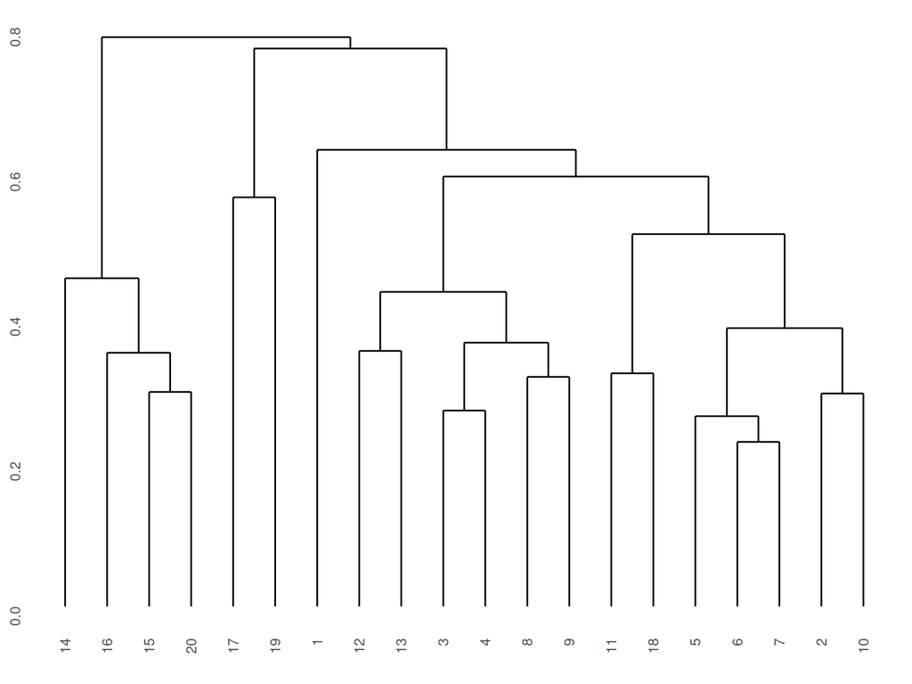

```r
library(ggdendro)
ggdendro::ggdendrogram(cls)
```

## クラスター分析(グループ追加)

```r
indiv <- "stand"
group <- "Use"
cls_group <-
  ecan::cls_add_group(
    cls = cls,
    df = dune_env_df,
    indiv = indiv,
    group = group)
```

## クラスター分析(グループ別で図示)

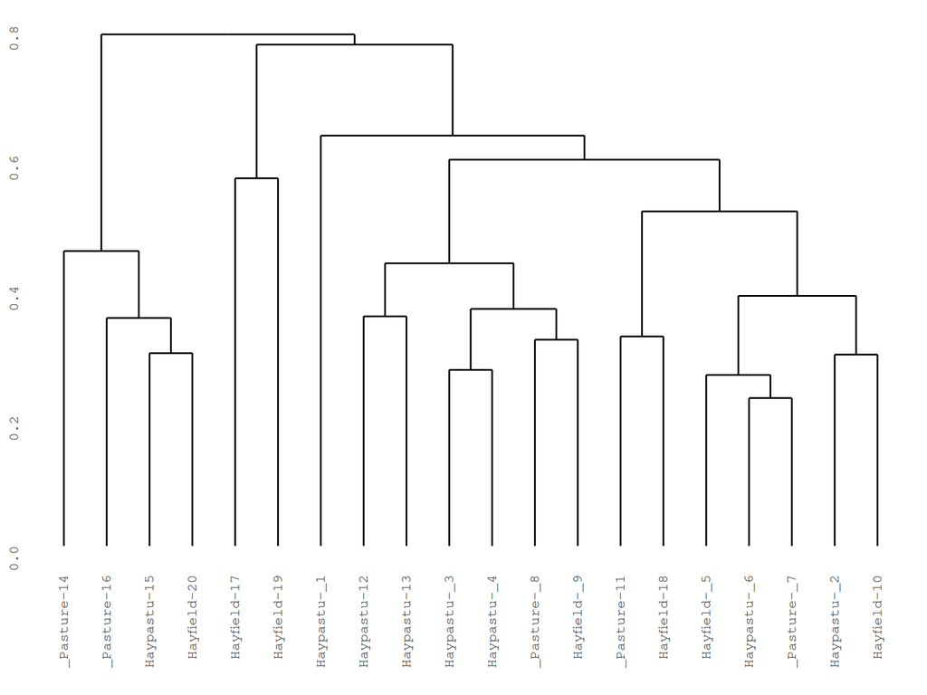

```r
ggdendro::ggdendrogram(cls_group) +
  ggplot2::theme(text = element_text(family = "mono")) # 等幅フォント
```

## クラスター分析(グループで着色)

```r
col <-
  ecan::cls_color(
    cls = cls,
    df = dune_env_df,
    indiv = indiv,
    group = group)
cls_colored <- stats::as.dendrogram(cls_group)
```

## クラスター分析(着色して図示，コード)

```r
par(family = "mono")  # 等幅フォント
plot(cls_colored)
dendextend::colored_bars(
  colors = col,
  cls_colored,
  group,
  y_shift = 0,
  y_scale = 3)
par(new = TRUE)
plot(cls_colored)
```

## クラスター分析(着色して図示)

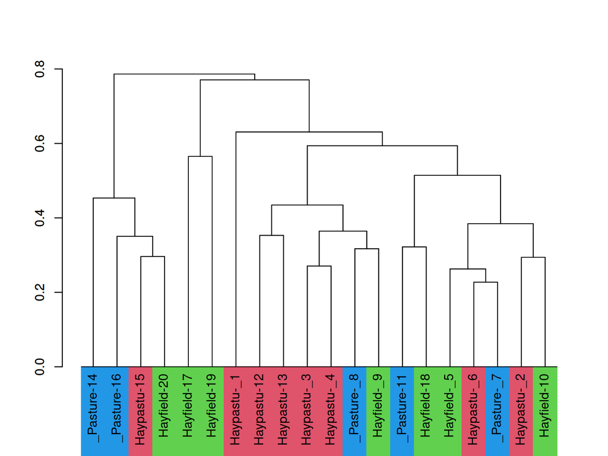

# 序列化(演習)

- nMDS
- Bray-Curtis距離
- 地点でプロット
- 種でプロット + 色付き

## 序列化：nMDS，Bray-Curtis距離

```r
ord_nmds <-
  df |>
  ecan::df2table(st = "stand", sp = "species", ab = "cover") |>
  ecan::ordination(
    o_method = "nmds",
    d_method = "bray")
```

## 序列化：地点の図示の準備

```r
ord_nmds_st <-
  ecan::ord_extract_score(ord_nmds, score = "st_scores") |>
  tibble::tibble() |>
  print(n = 10)
```

```
## # A tibble: 20 × 3
##         V1       V2 rowname
##      <dbl>    <dbl> <chr>
##  1 -0.424  -0.310   1
##  2 -0.258  -0.176   2
##  3 -0.0625 -0.206   3
##  4 -0.0804 -0.247   4
##  5 -0.306  -0.0139  5
##  6 -0.266   0.0761  6
##  7 -0.263  -0.00503 7
##  8  0.123  -0.0856  8
##  9  0.0349 -0.212   9
## 10 -0.244   0.0323  10
## # ℹ 10 more rows
```

## 序列化：地点の図示(コード)

```r
ord_nmds_st |>
  ggplot2::ggplot(
    ggplot2::aes(V1, V2, label = .data[["rowname"]])) +
  ggplot2::geom_text() +
  ggplot2::theme_bw()
```

## 序列化：地点の図示

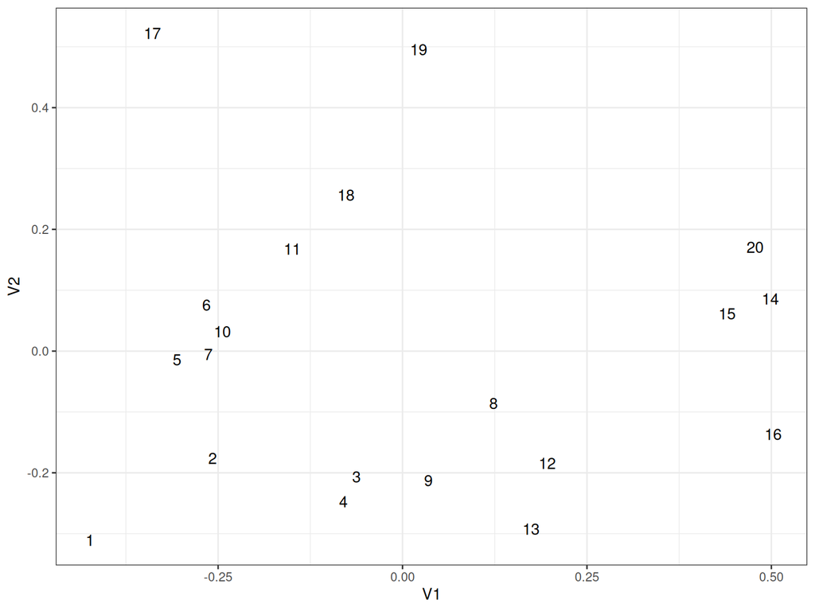

## 序列化：種の図示の準備

```r
indiv <- "species"
group <- "dummy_1"
ord_nmds_sp <-
  ecan::ord_add_group( # 抽出も実行
    ord = ord_nmds,
    score = "sp_scores",
    df = df,
    indiv = indiv,
    group = group)
```

## 序列化：種の図示用のデータ

```r
tibble::tibble(ord_nmds_sp)
```

```
## # A tibble: 30 × 5
##        V1      V2 species  dummy_1 dummy_6
##     <dbl>   <dbl> <chr>    <chr>   <chr>
##  1 -0.430 -0.0696 Achimill A       i
##  2 -0.206  0.254  Elymrepe E       e
##  3 -0.273  0.220  Lolipere L       e
##  4 -0.254  0.230  Poaprat  P       a
##  5 -0.179  0.332  Poatriv  P       i
##  6  0.146  0.364  Alopgeni A       e
##  7 -0.284  0.0629 Bellpere B       e
##  8 -0.381  0.0908 Bromhord B       o
##  9 -0.111  0.0733 Scorautu S       u
## 10 -0.158  0.155  Trifrepe T       e
## # ℹ 20 more rows
```

## 序列化：種の図示

```r
ord_nmds_sp |>
  ggplot2::ggplot(
    ggplot2::aes(V1, V2,
      label = .data[[indiv]])) +
  ggplot2::geom_point(
    ggplot2::aes(
      col = .data[[group]]),
      alpha = 0.4,
      size = 7) +
  ggplot2::geom_text() +
  ggplot2::theme_bw()
```

## 序列化：種の図示

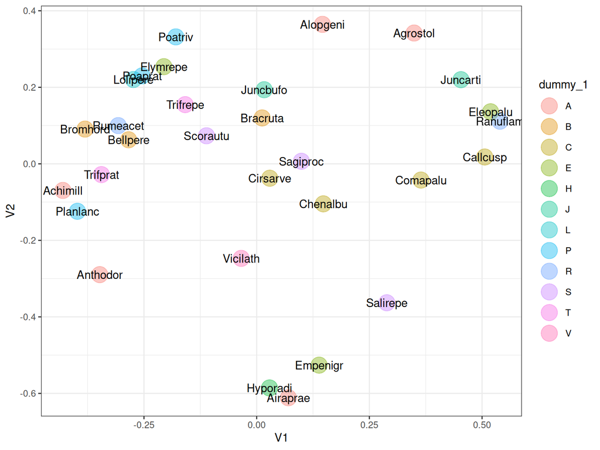

# 指標種分析(演習)

```r
  # `row_data = TRUE`でlabdsv::indval()のそのままの結果
isa_res_raw <-
  ecan::ind_val(df,
          group = "Management",
          row_data = TRUE)
  # 以下の出力は省略
isa_res_raw$relfrq # 種の出現頻度
isa_res_raw$relabu # 種の平均出現量
isa_res_raw$indval # 指標値
tibble(
  cls = isa_res_raw$maxcls,     # 最大値のクラス
  ind_val = isa_res_raw$indcls, # 指標値
  p = isa_res_raw$pval)         # p値
```

## 指標種分析の結果：整理した結果

```r
group <- "Management"
(isa_res <- ecan::ind_val(df, group = group))
```

```
## # A tibble: 30 × 4
##    Management species  ind.val p.value
##    <fct>      <chr>      <dbl>   <dbl>
##  1 SF         Elymrepe   0.188   0.677
##  2 SF         Alopgeni   0.547   0.043
##  3 SF         Agrostol   0.472   0.052
##  4 SF         Cirsarve   0.167   1
##  5 SF         Sagiproc   0.241   0.517
##  6 SF         Chenalbu   0.167   1
##  7 BF         Achimill   0.386   0.113
##  8 BF         Lolipere   0.45    0.079
##  9 BF         Poaprat    0.379   0.195
## 10 BF         Bellpere   0.362   0.127
## # ℹ 20 more rows
```

## 指標種分析の結果の図示(コード)

```r
isa_gg <-
  isa_res |>
   ggplot2::ggplot(
    ggplot2::aes(
      x = .data[[group]],
      y = .data[["ind.val"]],
      size = log(1 / (.data[["p.value"]] * 10)),
      label = .data[["species"]])) +
  ggplot2::geom_point() +
  ggrepel::geom_text_repel(
    ggplot2::aes(
      size = log(1 / (.data[["p.value"]] * 10), base = 5))) +
  ggplot2::theme_bw() +
    ggplot2::theme(legend.position = "none")
```

## 指標種分析の結果の図示

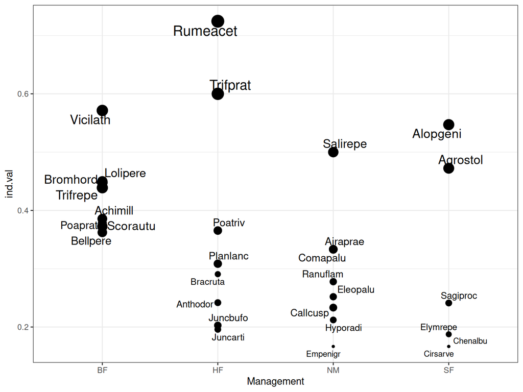

```r
isa_gg
```

# 引用文献

- Hadley, W., 2014, Tidy data. Journal of Statistical Software, 59, 1-23.
- Dufrene, M. and Legendre, P. 1997. Species assemblages and indicator species: the need for a flexible asymmetrical approach. Ecol. Monogr. 67, 345-366.

## 書籍

- 佐々木 雄大・小山 明日香・小柳 知代・古川 拓哉・内田 圭. 2015. 生物群集の構造と多様性の解析. 共立出版.
- Wildi, Otto. 2017. Data Analysis in Vegetation Ecology, 3rd ed. Cabi.
- 小林 四郎. 1995. 生物群集の多変量解析. 蒼樹書房. 絶版．中古がネット書店に．
- 伊藤 秀三(編). 2003. 群落の組成と構造. 朝倉書店. 1977年に出版し, 絶版．2003年に復刊し, 絶版． 中古がネット書店に．

## 全般的な解説

- 加藤 和弘. 1996. 生物群集の多変量解析とその地域環境計画への応用. ランドスケープ研究, 60, 46-55.
- 大垣俊一. 1999. 群集組成の多変量解析. Argonauta, 1, 15-26.
- 大垣俊一. 2008. 多様度と類似度、分類学的新指標. Argonauta. 15, 10-22.
- 土居 秀幸・岡村 寛. 2011. 生物群集解析のための類似度とその応用: Rを使った類似度の算出, グラフ化, 検定. 日本生態学会誌, 61, 3-20.

# 植生学会への入会案内

- 植生学会  
  http://shokusei.jp/baser/
- 入会案内  
  http://shokusei.jp/baser/contact/admission-and-withdrawal

# アンケートのお願い

- 匿名式
- URL(2つとも同じ)
  - https://forms.gle/WPXZ6p94dvDoJxQB6
  - https://docs.google.com/forms/d/e/1FAIpQLScXq-97_MIAFc30VLl6v5HQj8HEebAf__y_oTn7si2t2bSo6Q/viewform

# Rで自動化・効率化(宣伝)

- 松村 俊和. 2025.  
  Rによる自動化・効率化レシピ集. 森北出版.
  - https://github.com/matutosi/r-auto  
    (サポートページ)
  - https://www.amazon.co.jp/dp/4627858310/  
    (Amazon)